# In Course Exercise 8

Brooke Anderson

January 12, 2016

I’ve pulled in four datasets:

| Dataset | Description |
| --- | --- |
| `drinks` | Number of servings of different types of alcohol per country |
| `continents` | Continents of most countries |
| `gdp` | Gross domestic product of most countries |
| `wine` | Wine production for some countries |

All the files used for these are in this week’s `example_data` directory. More information about the data files are in that directory’s README file.

I have read these in from files and done some cleaning. Here are what each dataset looks like at this point:

```r
head(drinks)
```

```
##             country beer_servings spirit_servings wine_servings
## 1       Afghanistan             0               0             0
## 2           Albania            89             132            54
## 3           Algeria            25               0            14
## 4           Andorra           245             138           312
## 5            Angola           217              57            45
## 6 Antigua & Barbuda           102             128            45
##   total_litres_of_pure_alcohol
## 1                          0.0
## 2                          4.9
## 3                          0.7
## 4                         12.4
## 5                          5.9
## 6                          4.9
```

```r
head(continents)
```

```
##   Continent  Country      country
## 1    Africa  Algeria      Algeria
## 2    Africa   Angola       Angola
## 3    Africa    Benin        Benin
## 4    Africa Botswana     Botswana
## 5    Africa  Burkina Burkina Faso
## 6    Africa  Burundi      Burundi
```

```r
head(gdp)
```

```
##          Economy  US.dollars.      gdp        country
## 1  United States  17,419,000  17419000            USA
## 2          China  10,360,105  10360105          China
## 3          Japan   4,601,461   4601461          Japan
## 4        Germany   3,852,556   3852556        Germany
## 5 United Kingdom   2,941,886   2941886 United Kingdom
## 6         France   2,829,192   2829192         France
```

```r
head(wine)
```

```
##    AreaName   Value   country
## 1   Armenia    6422   Armenia
## 2   Albania   18000   Albania
## 3   Algeria   49800   Algeria
## 4 Argentina 1498400 Argentina
## 5 Australia 1231000 Australia
## 6   Austria  239195   Austria
```

Next, I merged the datasets all together. I limited to only the countries where I had drink consumption, continent, and GDP. I kept countries if I had everything except wine production, although I merged this value in for countries for which I had it.

The combined dataset now looks like this:

```r
head(drinks)
```

```
##             country beer_servings spirit_servings wine_servings
## 1       Afghanistan             0               0             0
## 2           Albania            89             132            54
## 3           Algeria            25               0            14
## 4           Andorra           245             138           312
## 5            Angola           217              57            45
## 6 Antigua & Barbuda           102             128            45
##       Continent    gdp total_litres wine_prod
## 1          Asia  20842          0.0        NA
## 2        Europe  13370          4.9     18000
## 3        Africa 214063          0.7     49800
## 4        Europe   3249         12.4        NA
## 5        Africa 131401          5.9        NA
## 6 North America   1269          4.9        NA
```

In total, the data now includes 185 countries spanning 6 continents (Asia, Europe, Africa, North America, South America, Oceania).

## Summary statistics on alcohol consumption

Here are some summary statistics for the different alcohol consumptions metrics, both overall and by continent. Each column shows the mean for that metric, with interquartile ranges shown in parentheses.

| Continent | N | Total (litres) | Beer (servings) | Spirits (servings) | Wine (servings) |
| --- | --- | --- | --- | --- | --- |
| All countries | 185 | 5 (1.4, 7.3) | 109 (21, 193) | 82 (5, 128) | 51 (1, 62) |
| Europe | 43 | 9 (6.65, 10.95) | 203 (137.5, 274.5) | 139 (85.5, 176) | 149 (70, 203.5) |
| South America | 12 | 6 (5.25, 7.375) | 175 (129.5, 198) | 115 (65.75, 148.75) | 62 (3, 98.5) |
| North America | 23 | 6 (4.3, 7) | 145 (80, 198) | 166 (101, 190.5) | 25 (5, 34) |
| Oceania | 13 | 3 (1, 2.6) | 92 (21, 105) | 37 (18, 50) | 37 (1, 23) |
| Africa | 52 | 3 (0.775, 4.875) | 63 (15, 77.5) | 17 (1, 19.75) | 17 (1, 13.25) |
| Asia | 42 | 2 (0.125, 2.475) | 39 (5, 61.5) | 63 (1, 100) | 9 (0, 8) |

Here are measures for each country (total litres of pure alcohol, then servings of beer, spirits, and wine). Countries are grouped by continent and ordered by total litres of pure alcohol consumed.

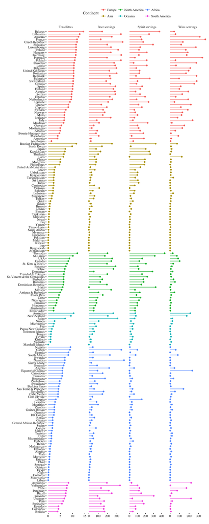

## Countries with low alcohol consumption

I classified a country as having low alcohol consumption if its serving values for wine, beer, and spirits were all below the 25<sup>th</sup> percentile for all countries. Low-alcohol-consumption countries were much more common in some continents than others:

| Continent | % low alcohol countries | Low-alcohol countries |
| --- | --- | --- |
| Asia | 26% | Afghanistan, Bangladesh, Indonesia, Iran, Iraq, Kuwait, Malaysia, Maldives, Myanmar, Pakistan, Yemen |
| Africa | 8% | Eritrea, Ethiopia, Libya, Mauritania |
| Oceania | 8% | Marshall Islands |
| Europe | 0% |  |
| North America | 0% |  |
| South America | 0% |  |

## Wine versus beer

Here is a graph comparing wine consumption to beer consumption. Each point represents a country; color corresponds to the country’s continent, and size corresponds with the total pure alcohol consumption in the country. Points to the right of the diagonal line are countries where more servings of wine are consumed than beer; to the left, more beer than wine.

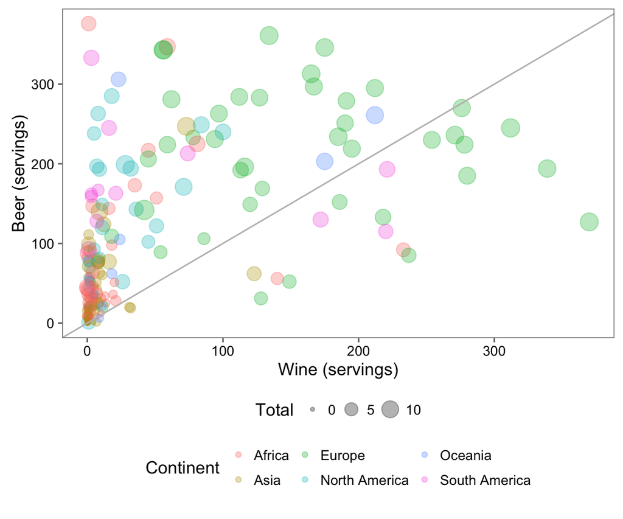

Most countries with more wine consumption than beer consumption are in Europe (Andorra, Croatia, Denmark, France, Georgia, Greece, Italy, Luxembourg, Montenegro, Portugal, Slovenia, Sweden, Switzerland). A few are in South America (Argentina, Chile, Uruguay), Africa (Equatorial Guinea, Sao Tome & Principe), and Asia (Laos, Lebanon, Qatar, Timor-Leste, Turkmenistan).

I calculated a wine-to-beer serving ratio for each country. Below is a histogram of those ratios.

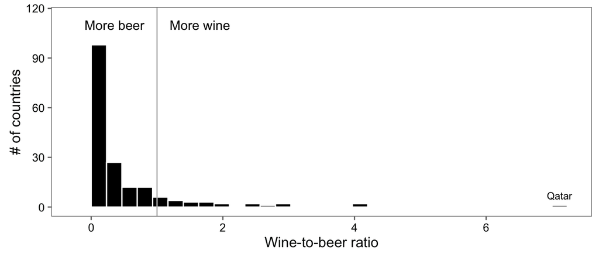

Most countries have more beer than wine. The country with the highest wine-to-beer ratio is Qatar, with 7 wine servings versus 1 beer serving.

Here is a table of the top five and bottom five wine-to-beer ratios:

|  | Country | Wine-to-beer ratio | Wine (servings) | Beer (servings) |
| --- | --- | --- | --- | --- |
| 1 | Qatar | 7 | 7 | 1 |
| 2 | Montenegro | 4.1 | 128 | 31 |
| 3 | Timor-Leste | 4 | 4 | 1 |
| 4 | France | 2.9 | 370 | 127 |
| 5 | Georgia | 2.9 | 149 | 52 |
| 6 | … | … | … | … |
| 171 | Bhutan | 0 | 0 | 23 |
| 172 | Rwanda | 0 | 0 | 43 |
| 173 | Uganda | 0 | 0 | 45 |
| 174 | Lesotho | 0 | 0 | 82 |
| 175 | Burundi | 0 | 0 | 88 |

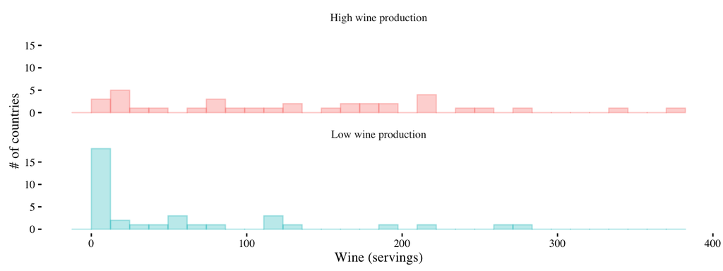

## Alcohol consumption versus GDP

Here are scatterplots of alcohol consumption (litres of pure alcohol) versus the GDP within each country (shown on a log10 scale):

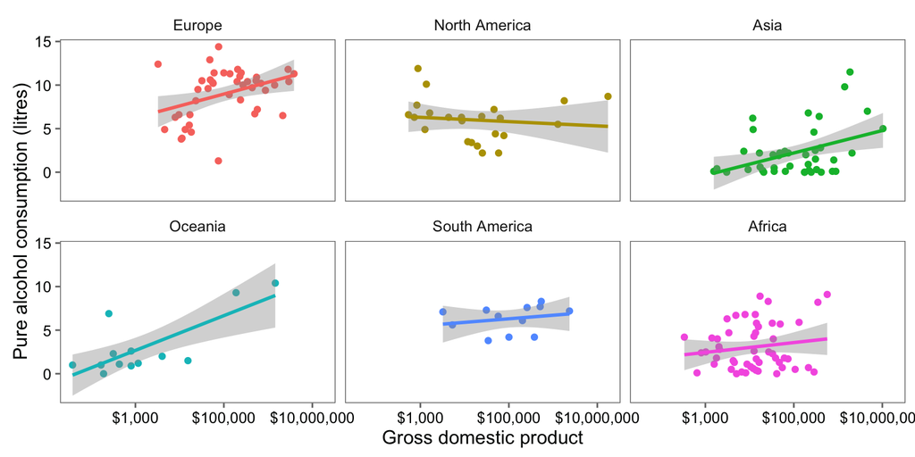

Generally, alcohol consumption is higher in countries with higher GDPs– North America is an exception.